## Project EDA

#### Sunho Kim

University of Washington iSchool

In this report, we are going to explore the datasets of unemployment data and exchange rates. For the unemployment data, we have a dataset from the Bureau of Lobor Statistics which contains unemployment rate of each month from 2007 to 2016. For example, the following shows how the data look like, and the value represents the percentage of umemployment. The dataset has total of 10 rows and 14 columns which represents 10 years and 12 months(+ year name and year average). The year average column was generated after data collection to provide a better understanding of a year.

```
##   Year Jan Feb Mar Apr May Jun Jul Aug Sep  Oct Nov Dec  yearAvg
## 1 2007 4.6 4.5 4.4 4.5 4.4 4.6 4.7 4.6 4.7  4.7 4.7 5.0 4.616667
## 2 2008 5.0 4.9 5.1 5.0 5.4 5.6 5.8 6.1 6.1  6.5 6.8 7.3 5.800000
## 3 2009 7.8 8.3 8.7 9.0 9.4 9.5 9.5 9.6 9.8 10.0 9.9 9.9 9.283333
## 4 2010 9.8 9.8 9.9 9.9 9.6 9.4 9.4 9.5 9.5  9.4 9.8 9.3 9.608333
## 5 2011 9.1 9.0 9.0 9.1 9.0 9.1 9.0 9.0 9.0  8.8 8.6 8.5 8.933333
## 6 2012 8.3 8.3 8.2 8.2 8.2 8.2 8.2 8.1 7.8  7.8 7.7 7.9 8.075000
```

To compare unemployment data with exchange rates of different countries, collecting exchange rate data was necessary. Web scraping skill was used to collect data from the IMF website. On their website, they have exchange rate of each day in a month, so it was necessary to calculate the average exchange rate of days in a month. By calculating average, it exactly matches with the shape of unemployment data, and allow easier comparison. In the dataset, values represent how much amount in a specific currency we can buy with one U.S. dollar. The dataset has the same shape with unemployment data, and the following gives an exmple(Russia) of exchange rate data. The year average column was also generated after data collection.

```
##   Year      Jan      Feb      Mar      Apr      May      Jun      Jul
## 1 2007 26.53018 26.32222 26.10818 25.80053 25.82066 25.91677 25.54094
## 2 2008 24.49572 24.50614 23.73540 23.51948 23.72712 23.63690 23.34841
## 3 2009 32.82957 35.81439 34.58812 33.55353 31.94327 31.05707 31.51314
## 4 2010 29.81564 30.16863 29.55650 29.18383 30.50610 31.19888 30.65324
## 5 2011 29.97515 29.28044 28.43418 28.06344 27.92965 27.98201 27.91966
## 6 2012 31.19683 29.82051 29.33676 29.49730 30.89465 32.89169 32.52507
##        Aug      Sep      Oct      Nov      Dec  yearAvg
## 1 25.62723 25.23578 24.88648 24.45294 24.57499 25.56807
## 2 24.18832 25.27456 26.43143 27.36092 28.18391 24.86736
## 3 31.68235 30.77346 29.43923 28.91175 30.03886 31.84540
## 4 30.40032 30.80617 30.33790 30.93658 30.85209 30.36799
## 5 28.75437 30.78175 31.25782 30.81805 31.50805 29.39205
## 6 31.96700 31.41509 31.09392 31.39609 30.75771 31.06605
```

For the dimension of unemployment dataset, we have the following:

```
## [1] 10 14
```

For the dimension of each of exchange rate datasets, we have the following:

```
## [1] 10 14
```

**Univariate Analysis**

Luckily, the datasets were retrieved from well organized industry in terms of data, there is not missing data. We had some null values for exchange rates since there were days when exchange market does not open; however, we calculated the average of days(with data) so we do not have missing data. For each variable(months) of the unemployment dataset, please see the following:

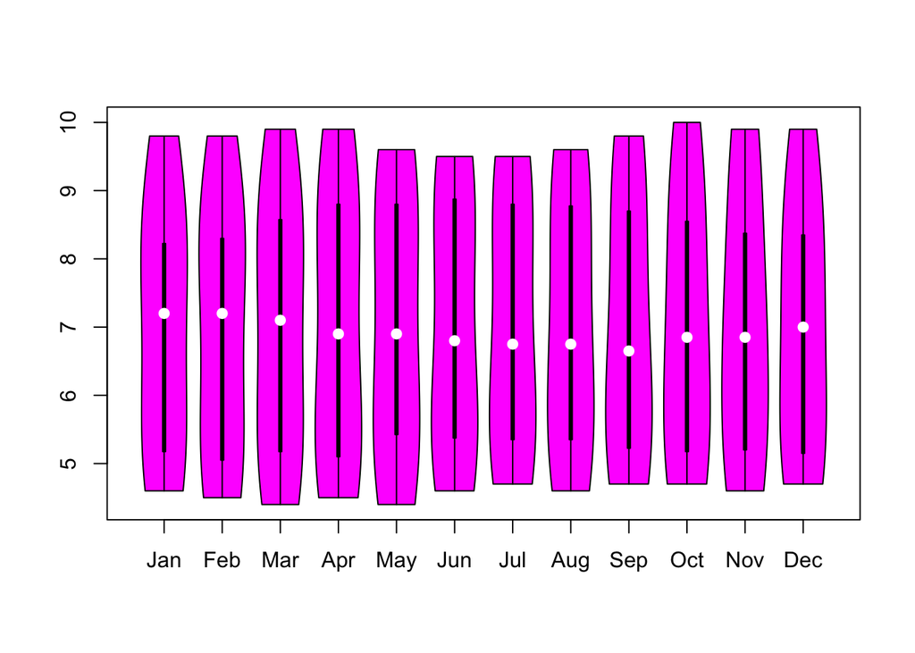

The general trend showed that unemployment rate gets lower until September and starts to increase after September. For a more mathmetical way of the overview of variables, please see the following:

```
##       Year           Jan             Feb            Mar
##  Min.   :2007   Min.   :4.600   Min.   :4.50   Min.   :4.400
##  1st Qu.:2009   1st Qu.:5.175   1st Qu.:5.05   1st Qu.:5.175
##  Median :2012   Median :7.200   Median :7.20   Median :7.100
##  Mean   :2012   Mean   :6.980   Mean   :6.96   Mean   :6.990
##  3rd Qu.:2014   3rd Qu.:8.225   3rd Qu.:8.30   3rd Qu.:8.575
##  Max.   :2016   Max.   :9.800   Max.   :9.80   Max.   :9.900
##       Apr            May             Jun             Jul
##  Min.   :4.50   Min.   :4.400   Min.   :4.600   Min.   :4.70
##  1st Qu.:5.10   1st Qu.:5.425   1st Qu.:5.375   1st Qu.:5.35
##  Median :6.90   Median :6.900   Median :6.800   Median :6.75
##  Mean   :6.99   Mean   :7.000   Mean   :7.020   Mean   :7.02
##  3rd Qu.:8.80   3rd Qu.:8.800   3rd Qu.:8.875   3rd Qu.:8.80
##  Max.   :9.90   Max.   :9.600   Max.   :9.500   Max.   :9.50
##       Aug             Sep             Oct              Nov
##  Min.   :4.600   Min.   :4.700   Min.   : 4.700   Min.   :4.600
##  1st Qu.:5.350   1st Qu.:5.225   1st Qu.: 5.175   1st Qu.:5.200
##  Median :6.750   Median :6.650   Median : 6.850   Median :6.850
##  Mean   :7.040   Mean   :6.990   Mean   : 6.990   Mean   :6.980
##  3rd Qu.:8.775   3rd Qu.:8.700   3rd Qu.: 8.550   3rd Qu.:8.375
##  Max.   :9.600   Max.   :9.800   Max.   :10.000   Max.   :9.900
##       Dec          yearAvg
##  Min.   :4.70   Min.   :4.617
##  1st Qu.:5.15   1st Qu.:5.394
##  Median :7.00   Median :6.767
##  Mean   :6.99   Mean   :6.996
##  3rd Qu.:8.35   3rd Qu.:8.719
##  Max.   :9.90   Max.   :9.608
```

Now when we are going to analyze the data by category. First, the following graph shows the general trend of unemployment rate by showing unemployment rates each year. As you see, the unemployment rate starts to increase and jumps in 2009. This is expected to be a result of the subprime mortgage crisis which started in December 2007.

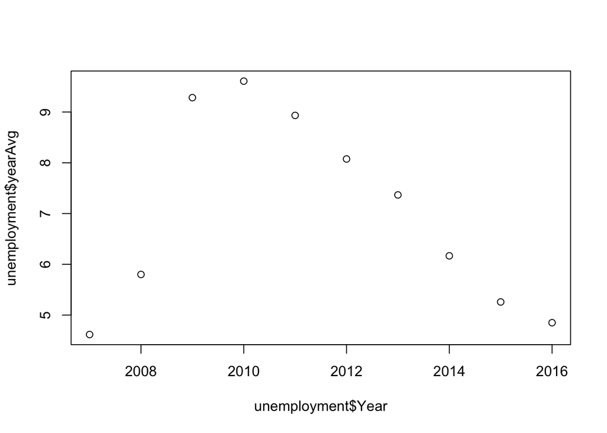

The unemployment rate decreases after 2010, and the following graph shows how unemployment rate can be related to the exchange rates in different countries. The truth is it is hard to see a relationship with bare eyes; however, we see some similar trends in two countries that can be related to unemployment in a specific range of time when unemployment rate increased dramatically. It seems to be a result of preference of U.S. Dollar which is one of riskless assets when world economy is in trouble.(to show the relationship rather than scale, Russian Ruble was divided by 2 and Korean Won was divided by 100)

[interactive chart not shown]

By looking at the dataset, it seems to need more specific datasets or more detailed approaches. Economy is affected by various reasons, and we may need some data about historically significant events that could affect the variables here. In this case, the subprime mortgage crisis seems to be a huge factor of the economy. Also with this exploration, it seems to be there are some countries those have currencies which almost have the same rate when buying a dollar. Further research on these datasets seems to be focused on the exchange rates of countries that have some correlation with unemployment rate in US.